# causal_modelling

```python
import pandas as pd
import numpy as np
from IPython.display import Image
```

## Intro: Causal models as Bayesian Networks

- A causal model has the same form as a probabilistic Bayesian network. It consists of a directed acyclic graph over the random variables in the domain.
- The model asserts that each variable X is governed by a causal mechanism that (stochastically) determines its value based on the values of its parents. That is, the value of $X$ is a (stochastic) function of the values of its parents.
- For a node $X$ and its parents $\textbf{U}$, the causal model has a stochastic function from the values of $\textbf{U}$ to the values of $X$. In other words, for each value u of $\textbf{U}$, it specifies a distribution over the values of $X$.
- We assume that causality flows in the direction of the edges, so that $X$’s value is actually determined via the stochastic function implied by $X$’s CPD.
- The assumption that CPDs correspond to causal mechanisms forms the basis for the treatment of intervention queries. When we intervene at a variable $X$, setting its value to $x$, we replace its original causal mechanism with one that dictates that it take the value $x$. This manipulation corresponds to replacing $X$’s CPD with a different one, where $X = x$ with probability 1, regardless of anything else.

## Multilated networks

- With the explanation of the mechanisms describing how a causal network works we can build a first working definition of a causal model. Which takes into accound a multilated network.
- $\textbf{Def}$: Given a bayesian network $\mathcal{B}$ let the mutilated network $\mathcal{B}_{Z=z}$ be obtained by removing all incoming edges into $Z$.
- Thus given a causal model $P_{Cs}$ the solution to the causal query of the form $P_{Cs}(Y|\mathrm{do}(z),x) = P_{Cs_{Z=z}}(Y|x)$ which suggests we can find the solution from the corresponding mutilated network.

- $P_{\mathrm{Cs}}$ - Causal distribution and let $P_{\mathrm{Obs}}$ represent observational distribution.
- $P_{\mathrm{Cs}}(Y|\mathrm{do}(z),x) = P_{\mathrm{Cs}_{Z=z}}(Y|x)$

## Augmented networks

- WHEN WE INTERVENE WE HAVE A NEW DISTRIBUTION!!!! LOOKING FOR A TRANSFORMATION BETWEEN $P$ and new $P'$. WE WANT TO ANSWER KNEW QUERIES.
- Simplest example, suppose some variable $X_i$ is forced to take on a value say $X_i = x_i'$. In some sense there is an external force $F_i$ which sets the variable $X_i = x_i'$.
- The effect of an atomic intervention $\mathrm{do}(X_i = x_i')$ is encoded by adding a link $F_i \rightarrow X_i$ where $F_i$ is a new variable taking on values $\{\mathrm{idle}, \mathrm{do}(x_i')\}$ where $x_i'$ ranges over the domain of $X_i$.
- The new parent of $X_i$ in the augmented graph $G'$ is represented by $Pa(X_i)' = Pa(X_i) \cup \{F_i\}$. We can place an arbitrary prior over $F_i$ and we will see this is practice is irrelevant.

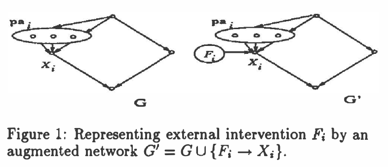

```python
Image("figs/causal_graph.png")
```

- The new conditional distribution on $x_i$ is given by

$$ P(x_i|pa_i')= \begin{cases} P(x_i|pa_i)\mathrm{\;if\;}F_i=idle\\ 0\mathrm{\;if\;} F_i = do(x_i')\mathrm{\;and\;}x_i \neq x_i'\\ 1\mathrm{\;if\;} F_i = do(x_i')\mathrm{\;and\;}x_i=x_i'\\ \end{cases} $$

- We can now let $P'$ be the new probability distribution over $G'$ which contains an arbitrary prior over $F_i$ and the new cpd $P(x_i|pa_i')$.